# Homework 1

Karen Zhou

9/11/2020

We first load the tidyverse package

```r
library(tidyverse)
```

We then import the data set hepA and save it

```r
hepA <- read_csv("hepA.csv")
```

#Question 1

There are 6 variables: disease, state, year, weeks reporting, count, population.

```r
head(hepA)
```

```
## # A tibble: 6 x 6
##   disease     state    year weeks_reporting count population
##   <chr>       <chr>   <dbl>           <dbl> <dbl>      <dbl>
## 1 Hepatitis A Alabama  1966              50   321    3345787
## 2 Hepatitis A Alabama  1967              49   291    3364130
## 3 Hepatitis A Alabama  1968              52   314    3386068
## 4 Hepatitis A Alabama  1969              49   380    3412450
## 5 Hepatitis A Alabama  1970              51   413    3444165
## 6 Hepatitis A Alabama  1971              51   378    3481798
```

#Question 2

There are 2346 observations in this data set

#Question 3

We use the filter function to filter out the data from Wisconsin from the year 1993

```r
hepA%>%
  filter(state == "Wisconsin", year == 1993)
```

```
## # A tibble: 1 x 6
##   disease     state      year weeks_reporting count population
##   <chr>       <chr>     <dbl>           <dbl> <dbl>      <dbl>
## 1 Hepatitis A Wisconsin  1993              27   346    5013015
```

#Question 4

We first add an variable, rate, by using the mutate function

```r
new_hepA <- hepA %>%
  mutate(rate = count / population)
```

We then grouped the data by state and then summarized the data and arranged them by ascending order

```r
new_hepA%>%
  group_by(state) %>%
  summarize(mean_rate = mean(rate)) %>%
  arrange(mean_rate)
```

```
## # A tibble: 51 x 2
##    state                mean_rate
##    <chr>                    <dbl>
##  1 Alabama              0.0000370
##  2 South Carolina       0.0000400
##  3 Wisconsin            0.0000423
##  4 Nebraska             0.0000426
##  5 North Dakota         0.0000469
##  6 Indiana              0.0000473
##  7 Iowa                 0.0000494
##  8 District Of Columbia 0.0000508
##  9 Minnesota            0.0000523
## 10 North Carolina       0.0000547
## # … with 41 more rows
```

The state with the lowest rate is Alabama

We then grouped the data by state and then summarized the data and arranged them by descending order

```r
new_hepA%>%
  group_by(state) %>%
  summarize(mean_rate = mean(rate))%>%
  arrange(desc(mean_rate))
```

```
## # A tibble: 51 x 2
##    state        mean_rate
##    <chr>            <dbl>
##  1 Alaska        0.000308
##  2 Oregon        0.000242
##  3 Arizona       0.000228
##  4 New Mexico    0.000224
##  5 California    0.000174
##  6 Washington    0.000148
##  7 Utah          0.000140
##  8 Nevada        0.000136
##  9 Idaho         0.000132
## 10 Rhode Island  0.000130
## # … with 41 more rows
```

The state with the highest rate is Alaska

#Question 5

We first grouped the data set by year and then summarized them

```r
yearly_averages <- new_hepA%>%
  group_by(year)%>%
  summarize(mean_rate = mean(rate))
```

We then created a plot graph by using the ggplot function

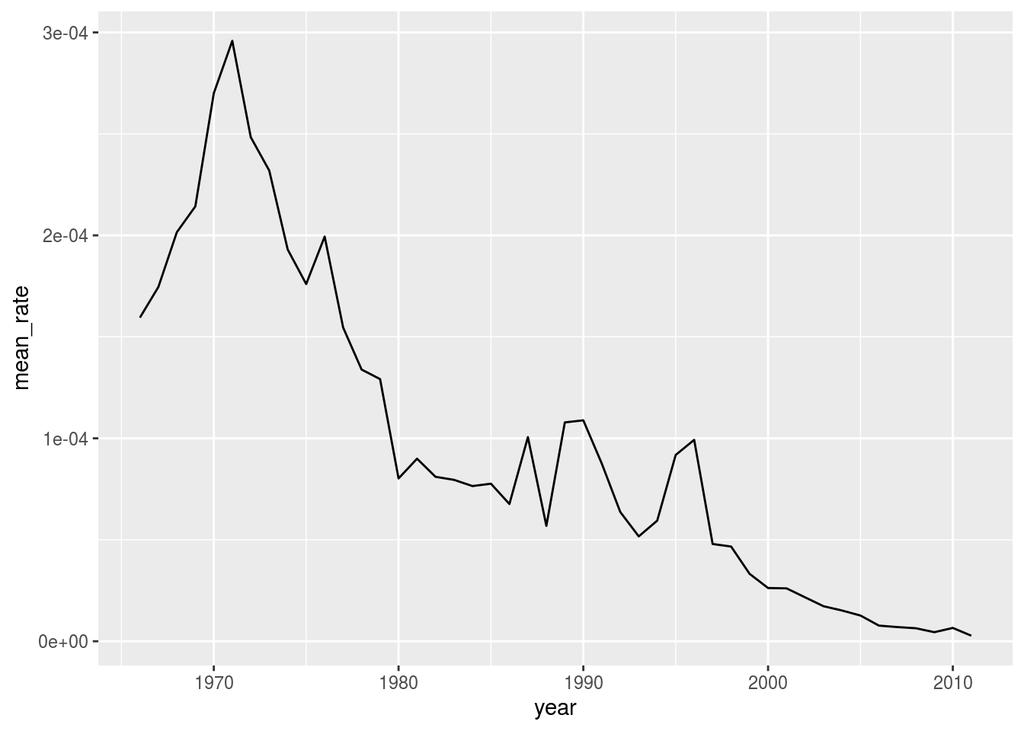

```r
ggplot(yearly_averages, aes(x = year, y = mean_rate)) + geom_line()
```

This plot graph is decreasing as the year increases, the mean rate is almost zer0 after around 2008. When did a vaccine became widely used?

#Question 6

We built the same plot with the added vertical line at the x intercept of 1995

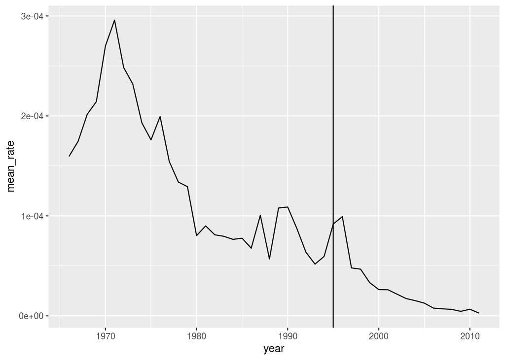

```r
ggplot(yearly_averages, aes(x = year, y = mean_rate)) + geom_line() + geom_vline(xintercept = 1995)
```